# STAT0010 Coursework — Student 23015888

# Exploratory analysis

The Services series is analysed. It represents the monthly United States trade balance in services from January 1992 to December 2024. A time series plot of the Services series shows a clear upward trend over time, indicating that the series is unlikely to be stationary in mean. The variability appears broadly stable, although fluctuations are somewhat larger in the later part of the sample. There are no obvious outliers, and all observations are retained for the analysis.

The autocorrelation function (ACF) of the original series shows very slow decay, remaining strongly positive even at relatively high lags. This behaviour is characteristic of a nonstationary series. The partial autocorrelation function (PACF) shows a strong spike at lag 1 followed by much smaller values, suggesting substantial persistence in the data.

To address the apparent nonstationarity, first differences of the series were considered. The differenced series fluctuates around zero, indicating that the trend has been effectively removed. Its variability is also substantially smaller than that of the original series. These features are consistent with a stationary series after differencing, and therefore support the use of an integrated model with one order of differencing. The ACF of the differenced series shows a rapid drop after lag 1, with most autocorrelations close to zero apart from a few small spikes. The PACF of the differenced series shows only weak and irregular behaviour, with no clear sustained pattern. These features are consistent with a short-memory stationary process.

Monthly boxplots show some variation across the year, but the medians and spreads are broadly similar across months, indicating no strong seasonal pattern. The boxplots of the differenced series also indicate only weak seasonal effects. There is therefore only limited evidence of seasonality from the exploratory analysis. On this basis, an initial ARIMA(1,1,1) model is proposed. This is a natural starting point, as the original series appears nonstationary. The differenced series exhibits short-memory dependence that can be captured by a low-order ARMA model.

# Model development

The initial ARIMA(1,1,1) model was fitted to capture the dependence structure of the differenced Services series. As the verification step in the Box–Jenkins procedure, the residuals from this initial model were examined. The main aim was to assess whether the model had removed the serial dependence. For a satisfactory model, the residuals should behave approximately as white noise, with no substantial autocorrelation remaining.

# Final model and forecasts

The final model selected is ARIMA(1,1,1) × (1,0,0)_{12}.

Let $Y_t$ denote the observed series and $\varepsilon_t$ white noise with variance $\sigma^2$. The model can be written as:

$$(1 - \phi_1 B)(1 - \Phi_1 B^{12})(1 - B)Y_t = (1 + \theta_1
B)\varepsilon_t,$$

with estimated parameters $\phi_1 = -0.7072$, $\theta_1 = 0.6732$, and $\Phi_1 = -0.0985$.

Substituting these estimates gives
$$(1 + 0.7072B)(1 + 0.0985B^{12})(1 - B)Y_t = (1 + 0.6732B)\varepsilon_t.$$
The estimated innovation variance is $\sigma^2 = 0.3294$, as obtained from the fitted model output.

Forecasts for the next 12 months (January 2025 to December 2025) were obtained using the fitted model. The point forecasts remain relatively stable, fluctuating around approximately 25.7, indicating that the model predicts a continuation of the recent level of the series rather than further strong growth or decline.

The associated 95% prediction intervals were constructed using the standard formula

$$\hat{Y}_{T+h} \pm 1.96 \cdot \mathrm{SE}(\hat{Y}_{T+h})$$

The prediction intervals widen steadily as the forecast horizon increases, reflecting increasing forecast uncertainty. For example, the standard error increases from approximately 0.57 for January 2025 to around 1.95 for December 2025, leading to substantially wider prediction intervals at longer horizons.

The numerical values of the forecasts and their corresponding 95% prediction intervals are provided in Part 5.

# Caveats and limitations

Although the selected ARIMA(1,1,1) × (1,0,0)_{12} model provides a reasonable fit to the data, there are several limitations.

First, the model assumes that the underlying data-generating process is linear and characterised by constant parameters over time. In practice, macroeconomic series such as the United States services trade balance are influenced by structural changes, policy shifts, and external shocks. For example, events such as financial crises or changes in global trade conditions may alter the behaviour of the series in ways that are not captured by a fixed-parameter ARIMA model. This may reduce the reliability of forecasts, particularly over longer horizons.

Second, although a seasonal autoregressive term at lag 12 has been included, the model only captures a relatively simple form of seasonality. The exploratory analysis suggested that seasonal effects are weak, and it is therefore possible that the seasonal component is either insufficient to capture more complex seasonal patterns or unnecessary. Any remaining seasonal structure not accounted for by the model may lead to residual dependence and reduced forecast accuracy.

Third, the model is purely univariate and does not incorporate any external explanatory variables. In reality, the services trade balance is likely to depend on a range of economic factors, such as exchange rates, global demand, and domestic economic conditions. By ignoring these factors, the model may fail to capture important drivers of variation, limiting its predictive performance.

Finally, the prediction intervals are based on the assumption that the model is correctly specified and that the innovations are approximately normally distributed. If these assumptions are violated, the nominal 95% prediction intervals may not achieve correct coverage. In addition, the increasing width of the prediction intervals over time, as observed in Part 3, highlights the growing uncertainty associated with longer-term forecasts.

Overall, while the model provides a simple and interpretable framework for short-term forecasting, its assumptions and limitations should be carefully considered when interpreting the results.

# Code and software output

## Code to read data, fit the final model and produce forecasts

```r
library(forecast)
Balances <- read.csv("USTradeBalances.csv", header = TRUE)
Y <- Balances$Services

fit <- arima(Y,
             order = c(1,1,1),
             seasonal = list(order = c(1,0,0), period = 12),
             include.mean = FALSE)

pred <- predict(fit, n.ahead = 12)

forecast_table <- data.frame(
  Month = c("2025-01","2025-02","2025-03","2025-04","2025-05","2025-06",
            "2025-07","2025-08","2025-09","2025-10","2025-11","2025-12"),
  Forecast = pred$pred,
  SE = pred$se,
  Lower95 = pred$pred - 1.96 * pred$se,
  Upper95 = pred$pred + 1.96 * pred$se
)

print(fit)
print(forecast_table)
```

## Software output for the final model

The following output summarises the fitted ARIMA model, as produced by the R function arima().

```
##
## Call:
## arima(x = Y, order = c(1, 1, 1), seasonal = list(order = c(1, 0, 0), period = 12),
##     include.mean = FALSE)
##
## Coefficients:
##           ar1     ma1     sar1
##       -0.7072  0.6732  -0.0985
## s.e.   0.2566  0.2662   0.0507
##
## sigma^2 estimated as 0.3294:  log likelihood = -341.19,  aic = 690.39
```

## Software output giving forecasts and prediction intervals

The following output provides the forecasts and associated 95% prediction intervals.

```
##      Month Forecast        SE  Lower95  Upper95
## 1  2025-01 25.78162 0.5738934 24.65679 26.90645
## 2  2025-02 25.71880 0.7979301 24.15486 27.28275
## 3  2025-03 25.64710 0.9795512 23.72718 27.56702
## 4  2025-04 25.73475 1.1275441 23.52476 27.94473
## 5  2025-05 25.71092 1.2613267 23.23872 28.18312
## 6  2025-06 25.75454 1.3802323 23.04928 28.45980
## 7  2025-07 25.75479 1.4909785 22.83247 28.67711
## 8  2025-08 25.73281 1.5931875 22.61017 28.85546
## 9  2025-09 25.70339 1.6897979 22.39138 29.01539
## 10 2025-10 25.73983 1.7807903 22.24948 29.23018
## 11 2025-11 25.70049 1.8676141 22.03996 29.36101
## 12 2025-12 25.73669 1.9504009 21.91390 29.55948
```

## Formula for 95% prediction intervals

The 95% prediction intervals are calculated as: $\hat{Y}_{t+h} \pm 1.96 \times \text{SE}(\hat{Y}_{t+h})$

# Graphs and / or Tables

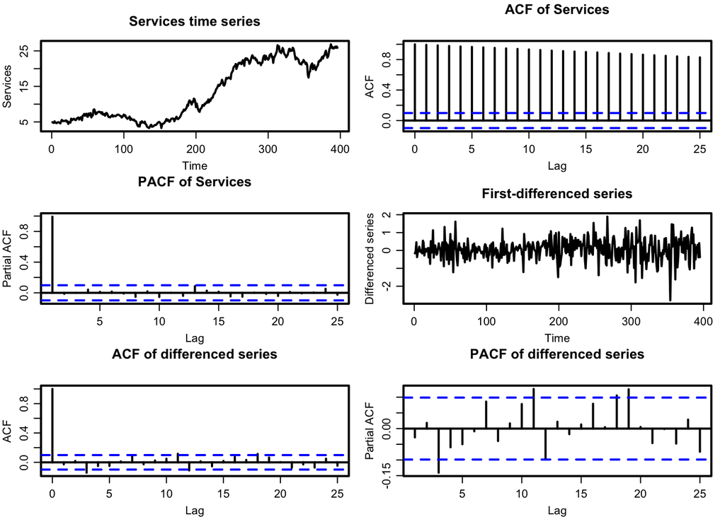

Time series plot, ACF and PACF of the Services series, together with the first-differenced series and corresponding autocorrelation functions used in model identification.

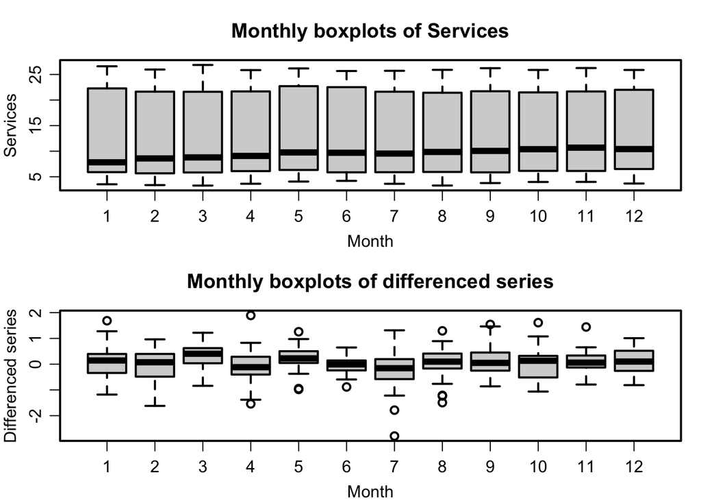

Monthly boxplots of the Services series and its first-differenced series, used to assess seasonal patterns.